# 200C Section W2: Potential Outcomes, Randomized Experiment

Soonhong Cho

April 8, 2022

## 1. Practice with Potential Outcomes

> Consider a randomized expriment with six observations, of which three units were randomly assigned to treatment via complete randomization (exactly half of units are treated). We use $D_i \in {0, 1}$ and $Y_i$ to denote the treatment (1 for treatment and 0 for control) and the observed outcome for unit $i$, respectively.
1. The table below shows the data observed from this experiment, augmented with columns for potential outcomes and the individual treatment effect (unit-level effect). Let’s fill in all the cells based on the observed information, denoting unknown information with “?”. Think about how $D_i$ function as “switch” that determines whether you observe $Y_{1i}$ or $Y_{0i}$.

   | $i$ | $Y_{0i}$ | $Y_{1i}$ | $\tau_i$ | $D_i$ | $Y_i$ |
   | --- | --- | --- | --- | --- | --- |
   | 1 |  |  |  | 1 | 8 |
   | 2 |  |  |  | 0 | 2 |
   | 3 |  |  |  | 0 | 4 |
   | 4 |  |  |  | 1 | 6 |
   | 5 |  |  |  | 0 | 12 |
   | 6 |  |  |  | 1 | 10 |

[output not shown]

<sup>a</sup> counterfactual values are unobserved (grey-colored)

- There are lots of ?. So, causal inference is “missing data problem” in such sense. The potential outcomes are pre-treatment characteristics, i.e., they are fixed attributes of the units. (Let’s be repetitive a little bit) They are latent, ready to be popped up in response to treatment. They don’t change when you change treatment, or you do anything, they are what would happen under a given treatment. The treatment doesn’t change the potential outcomes, it changes which potential outcomes you see. We can observe only one potential outcomes out of two for each unit simultaneously – which is called “fundamental problem of causal inference (Holland 1986)” (in many cases potential outcomes are more than two; they can be even almost infinite in some setting, e.g., “panel” or “cross-sectional time-series” setting with large time frame).
2. Let’s define the (population) average treatment effect for the treated ($\tau_{ATT}$) and propose an unbiased estimator for this estimand. Then, using the data in the table, let’s estimate the quantity of interest.
- The estimand is
  $$\tau_{ATT} = \mathbb{E}[Y_{1i} - Y_{0i}|D_i=1].$$
  Given randomization of treatment, an unbiased estimator is the difference-in-means for the treated and control! Why? Recall that random assignment guarantees **ignorability**:
  $$\{Y_{1i}, Y_{0i}\} \perp\!\!\!\perp D_i$$
  (jargon alert! a.k.a. “exchangeability,” “unconfoundedness,” “no unmeasured confounder,” “exogeneity,” “no omitted variable,” etc.): the potential outcomes are independent of the treatments, or treatment status $D_i$ conveys no information whatsoever about the potential values of $Y_{1i}, Y_{0i}$. It makes the treated and untreated units identical in terms of potential outcomes on average; the treatment group and control group are “exchangeable”; the two groups are “balanced” on observables and unobservables. Thus, we have
  $$\mathbb{E}[Y_{1i}] = \mathbb{E}[Y_{1i}|D_i=1] = \mathbb{E}[Y_{1i}|D_i=0],$$
  and similar result holds for untreated potential outcomes. In this sense, randomization makes the two groups “comparable.” In this case, **ATE=ATT**, as follows:
  $$\begin{align*}
  \tau_{ATT} &= \mathbb{E}[Y_{1i}-Y_{0i}|D_i=1] \\
  &= \underbrace{\mathbb{E}[Y_{1i}|\color{red}{D_i=1}]}_{(1)} - \underbrace{\mathbb{E}[Y_{0i}|\color{red}{D_i=1}]}_{(2)} & (\text{linearity of expectation}) \\
  &= \mathbb{E}[Y_{1i}] - \mathbb{E}[Y_{0i}] & (\text{ignorability, by randomization}) \\
  &= \mathbb{E}[Y_{1i} - Y_{0i}] = \tau_{ATE}
  \end{align*}$$
  What are (1) and (2) in words: (1) average of treated potential outcomes among treated units and (2) average of untreated potential outcomes among treated units.
- The estimator is **difference-in-means**:
  $$\hat{\tau}_{ATE} = \underbrace{\frac{1}{n_1}\sum_{i=1}^{n}D_iY_i}_{\text{average among treated}} - \underbrace{\frac{1}{n_0}\sum_{i=1}^{n}(1-D_i)Y_i}_{\text{average among control}},$$
  where $n_1$ is the number of treated units (so $\sum_{i}^{n}D_i=n_1$).
- Estimation: just plugging in the data gives us an estimate:

$$\frac{1}{3}(\underbrace{1 \cdot 8 + 0 \cdot 2 + 0 \cdot 4 + 1 \cdot 6 + 0 \cdot 12 + 1 \cdot 10}_{\sum_{i=1}^{n}D_iY_i}) - \frac{1}{3}(\underbrace{0 \cdot 8 + 1 \cdot 2 + 1 \cdot 4 + 0 \cdot 6 + 1 \cdot 12 + 0 \cdot 10}_{\sum_{i=1}^{n}(1-D_i)Y_i}) = \frac{1}{3}(8+6+10) - \frac{1}{3}(2+4+12)=2$$

```r
#DiM estimator
tab %>% summarize(dim = mean(Y[D == 1]) - mean(Y[D == 0]))
```

```
## # A tibble: 1 × 1
##     dim
##   <dbl>
## 1     2
```

## 2. Identification?

- Recall that the goal of causal inference is to learn about a counterfactual (inherently unobservable) quantity of interest using finite, *observed* data. Thus, causal inference involves two inferential hurdles:
  1. **Identification**: If you can observe data from an *entire population* (or, *infinite* data), can you learn about your quantity of interest?
  2. **Estimation**: Given your finite amount of data on a *sample*, how well can you learn about your quantity of interest?
- Generally, the goal of identification analysis (Manski 1995, 2007) is to establish the domain of consensus among researchers with regard to what can be learned about causal quantities of interest from the data alone (e.g., using difference-in-means estimator to get ATE in classical randomized experiment is unquestionable: nobody argues against it). Identification problems should be handled *before* the estimation and statistical inference in finite sample.
- Why useful: identification analysis can formally characterize the roles of identification assumptions—so that we can evaluate the extent to which the conclusions of research depend on assumptions (explicitly or implicitly) imposed by researcher.
- We want to build a bridge from what we want to what we can get: we start by writing down formally the causal quantity of interest (estimand) and then see what changes we need to “turn it into” fully observable quantities (summarized by estimator) that can be computed from data. At each intermediate step (from estimand to fully observables) we just use some algebra and statistical tricks, with invoking our identification assumptions.

**Example 1: Classical Randomized Experiment**

1. Identification of **ATE** with Difference-in-Means estimator
   $$\begin{align*}
   \tau_{ATE} &= \mathbb{E}[Y_{1i}-Y_{0i}] \\
   &= \mathbb{E}[Y_{1i}] - \mathbb{E}[Y_{0i}] & (\text{linearity of expectation}) \\
   &= \mathbb{E}[Y_{1i}|\color{red}{D_i=1}] - \mathbb{E}[Y_{0i}|\color{red}{D_i=0}] & (\text{ignorability:}\{y_{1i}, y_{0i}\} \perp\!\!\!\perp D_i) \\
   &= \underbrace{\mathbb{E}[Y_{i}|D_i=1] - \mathbb{E}[Y_{i}|D_i=0]}_{\text{observed difference in means}} & (\text{consistency, SUTVA}) \\
   &= \frac{1}{n_1}\sum_{i=1}^{n}D_iY_i - \frac{1}{n_0}\sum_{i=1}^{n}(1-D_i)Y_i &(\text{sample analog})\\
   &= DiM
   \end{align*}$$
- We needed ignorability ($\{y_{1i}, y_{0i}\} \perp\!\!\!\perp D_i.$), consistency ($Y_{di}=Y_i|D_i=d$), and SUTVA (no interference and one-version-of-treatment) assumptions for our identification.
2. Identification of **ATT** with Difference-in-Means estimator
   $$\begin{align*}
   \tau_{ATT} &\equiv \mathbb{E}[Y_{1i} - Y_{0i}|D_i=1] \\
   &= \mathbb{E}[Y_{1i}|D_i=1] - \mathbb{E}[Y_{0i}|\color{red}{D_i=1}] &\text{(linearity of expectation)} \\
   &= \mathbb{E}[Y_{1i}|D_i=1] - \mathbb{E}[Y_{0i}|\color{red}{D_i=0}] &\text{(a weaker ignorability :}Y_{0i} \perp\!\!\!\perp D_i) \\
   &= \mathbb{E}[Y_{i}|D_i=1] - \mathbb{E}[Y_{i}|D_i=0] &\text{(consistency, SUTVA)} \\
   &= DiM.
   \end{align*}$$
- We needed only half of the ignorability assumption to identify the ATT: $Y_{0i} \perp\!\!\!\perp D_i$. The ignorability assumption is used only for moving from the second line to the third line, the terms colored red. It means that we do not have to assume that treated potential outcomes are ignorable, so it’s a weaker assumption than ATE.
3. Identification of **ATC** with Difference-in-Means estimator
   $$\begin{align*}
   \tau_{ATC} &\equiv \mathbb{E}[Y_{1i} - Y_{0i}|D_i=0] \\
   &= \mathbb{E}[Y_{1i}|\color{red}{D_i=0}] - \mathbb{E}[Y_{0i}|D_i=0] &\text{(linearity of expectation)} \\
   &= \mathbb{E}[Y_{1i}|\color{red}{D_i=1}] - \mathbb{E}[Y_{0i}|D_i=0] &\text{(a weaker ignorability: }Y_{1i} \perp\!\!\!\perp D_i) \\
   &= \mathbb{E}[Y_{i}|D_i=1] - \mathbb{E}[Y_{i}|D_i=0] &\text{(consistency, SUTVA)} \\
   &= DiM.
   \end{align*}$$
- Similar to the ATT case, another weaker ignorability assumption is required, but now for only treated potential outcomes: $Y_{1i} \perp\!\!\!\perp D_i$. We don’t have to assume that untreated potential outcomes are ignorable.
- Takeaway: First, identification analysis clarifies what assumptions are required to get to the inferential goal. Second, we needed stronger identification assumption for ATE than ATT or ATC. In most cases ATE is more desirable estimand as it speaks to the whole population, whereas ATT and ATC are for some subpopulation, namely those who are treated/untreated (but ATT is often useful). **To make a stronger causal claim, we need stronger assumption(s)!**
- Law of decreasing credibility (Manski): The credibility of inference decreases with the strength of the assumptions maintained.

**Example 2: Stratified (Block) Randomized Experiment**

- The basic idea: if you have data on pre-treatment characteristics $X_i$, why leave it to “pure chance” to balance them?
- The basic procedure is as follows:
  1. Blocking (Stratification): create groups of similar units based on pre-treatment covariates (e.g., age, gender, region, etc.)
  2. Block (Stratified/Conditional) randomization: completely randomize treatment assignment within each group.
- Thus, you effectively run a separate experiment within each stratum! It can be seen as a form of covariate adjustment *by design*.
- We’ll see later for few weeks: Selection on Observables (SOO) is an attempt to approximate stratified randomization in observational setting! So, understanding block stratified randomization is important (Beyond its practical value, i.e., efficiency gain due to blocking—blocking tends to reduce sampling variability when we have covariates that we think might predict outcomes and improves precision of the ATE estimate. But let’s skip at this time. You’ll learn this in greater detail in PS200E.)
- Identification of **ATE** with weighted average of block-specific Difference-in-Means
- Our identification assumption is (within-block) conditional ignorability:
  $$\{Y_{1ij}, Y_{0ij}\} \perp\!\!\!\perp D_i|J_i,$$
  where $J$ is the blocking variable. It’s guaranteed by random assignment of treatment within blocks.
  $$\begin{align*}
  \tau_{ATE} &\equiv \mathbb{E}[Y_{1ij} - Y_{0ij}] \\
  &= \mathbb{E}_J[ \mathbb{E}[Y_{1ij} - Y_{0ij}|J_j=j] ] &\text{(law of iterated expectation)} \\
  &= \mathbb{E}_J[ \mathbb{E}[Y_{1ij}|J_j=j] - \mathbb{E}[Y_{0ij}|J_j=j] ] &\text{(linearity of expectation)} \\
  &= \mathbb{E}_J[ \mathbb{E}[Y_{1ij}|J_j=j, \color{red}{D_i=1}] - \mathbb{E}[Y_{0ij}|J_j=j, \color{red}{D_i=0}] ] &\text{(conditional ignorability)} \\
  &= \mathbb{E}_J[ \mathbb{E}[Y_{ij}|J_j=j, D_i=1] - \mathbb{E}[Y_{ij}|J_j=j, D_i=0] ] &\text{(consistency, SUTVA)} \\
  &= \sum_{j=1}^J \frac{n_j}{n}\hat{\tau}_j, \text{ where } \hat{\tau}_j = \frac{1}{n_{1j}} \sum_{i=1}^{n_j} D_{ij}Y_{ij} - \frac{1}{n_{0j}} \sum_{i=1}^{n_j} (1-D_{ij})Y_{ij} &(\text{sample analog})
  \end{align*}$$
  where $n$ is the number of units, $J$ is the number of blocks, and $n_{1j}$ is the number of treated units in each block $j$. Basically, we expressed ATE as a weighted average of the block-wise ATEs, weighted by the relative size of each block. We’ll call this idea **“subclassification estimator”** in the context of Selection on Observable in observational world.
- When we moved from the third to fourth line, we used the fact that potential outcomes $Y_{dij}$ are independent of treatment $D_i$ within each block $j$ (recall that $\mathbb{E}[A]=\mathbb{E}[A|B]$ if $A \perp\!\!\!\perp B$). All quantities in the last line are then observable, so the ATE is identified under blocking.

## What if we knew all the potential outcomes (hypothetical scenario)

**1. Classical Randomized Experiment**

```r
#a "science table" with 10 samples from N=1000 under classical randomized experiment
#let's use tibble() function to make a dataset from scratch
sample_data <- tibble(i = 1000, #unit index
                      Y0 = rnorm(1000), #untreated potential outcomes (suppose they're pure random noise)
                      Y1 = Y0 + 1,  #treated potential outcomes
                      tau = Y1-Y0) %>% #individual treatment effect (we set up it as 1)
  mutate(D = sample(c(0, 1), 1000, replace = TRUE, prob = c(.5, .5))) %>% #simple random assignment
  mutate(Y = if_else(D == 1, Y1, Y0)) #observed outcome: Y = D*Y1 + (1-D)*Y0
```

| $i$ | $Y_{0i}$ | $Y_{1i}$ | $\tau_i$ | $D_i$ | $Y_i$ |
| --- | --- | --- | --- | --- | --- |
| 1000 | 0.323 | 1.323 | 1 | 0 | 0.323 |
| 1000 | -1.623 | -0.623 | 1 | 0 | -1.623 |
| 1000 | 0.379 | 1.379 | 1 | 1 | 1.379 |
| 1000 | 0.252 | 1.252 | 1 | 0 | 0.252 |
| 1000 | -0.701 | 0.299 | 1 | 0 | -0.701 |
| 1000 | 0.247 | 1.247 | 1 | 1 | 1.247 |
| 1000 | 0.500 | 1.500 | 1 | 0 | 0.500 |
| 1000 | 0.127 | 1.127 | 1 | 0 | 0.127 |
| 1000 | -0.091 | 0.909 | 1 | 0 | -0.091 |
| 1000 | -2.053 | -1.053 | 1 | 0 | -2.053 |

<sup>a</sup> counterfactual values are unobserved (grey-colored)

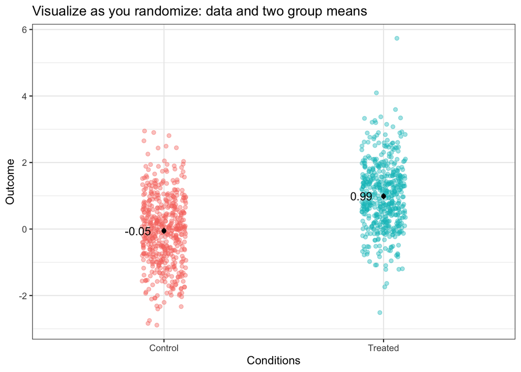

Let’s make a function to run a classical randomized experiment.

```r
classic_experiment <- function(n=100){
  tibble(Y0 = rnorm(n), Y1 = Y0 + 1) %>% #true treatment effect is set to 1
    #simple random assignment: each subject has an identical probability of being treated
    mutate(D = sample(c(0, 1), n, replace = TRUE, prob = c(.5, .5))) %>%

    #if you want complete random assignment: exactly N_1 of N units are treated with equal probability
    #mutate(D = sample(rep(c(0, 1), each = n()/2), n(), replace = FALSE)) %>%

    mutate(Y = if_else(D == 1, Y1, Y0)) %>% #observed outcome
    summarize(estimand = mean(Y1 - Y0), #our goal: average treatment effect (ATE)
              estimate = mean(Y[D == 1]) - mean(Y[D == 0]), #estimator: difference-in-means
              bias = estimate-estimand) %>% #bias of one particular experiment
    as_vector()
}
classic_experiment(n=1000) #run an experiment
```

```
##   estimand   estimate       bias
## 1.00000000 1.05797034 0.05797034
```

Recall that DiM is our “estimator”. Let’s check if our estimator DiM is unbiased for ATE: let’s calculate $\mathbb{E}[DiM - ATE]$ with 1000 experiments.

```r
mean(replicate(1000, classic_experiment(n=100), simplify=TRUE)[3, ]) #if [mean of bias]=0, then unbiased
```

```
## [1] -0.01133759
```

The sampling distribution (the hypothetical distribution under repeated sampling) of our estimator with 1,000 repetition DiM looks like:

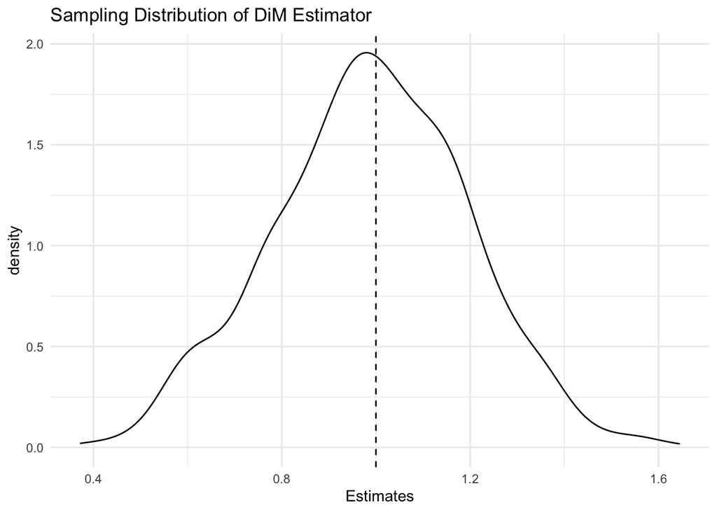

Another desirable property of any estimator is consistency ($\hat{\theta} \xrightarrow{p} \theta$). We expect that the **standard error** (the standard deviation of the sampling distribution) would decrease as sample size increases.

```r
library(purrr)
#We want to repeat 1000 experiment for various sample size
#Maybe we can use 1)for loop or 2)dplyr with `replicate` function or 3)most recent `map()` method
#In its essence `map()` family in `purrr` package is the tidyverse equivalent of the
#base R apply family of functions
consist <- 10^c(1:4) %>% #get sampling distribution w/ r=1000 for n=10, 100, 1000, and 10000
  set_names(paste("Size: ", 10^c(1:4), sep="")) %>% #set names for each size
  #`map_dfc()` store each of its results as column (map_df() stores results in rows)
  #we will have a tibble with 4 columns, one for each sample size
  map_dfc(function(n) replicate(100, classic_experiment(n)["estimate"]))
head(consist, 5)
```

```
## # A tibble: 5 × 4
##   `Size: 10` `Size: 100` `Size: 1000` `Size: 10000`
##        <dbl>       <dbl>        <dbl>         <dbl>
## 1      1.27        0.495        1.07          0.996
## 2      0.955       1.17         1.02          0.986
## 3      1.58        0.873        1.16          0.992
## 4      0.291       0.932        0.884         1.00
## 5      1.20        0.737        1.13          0.999
```

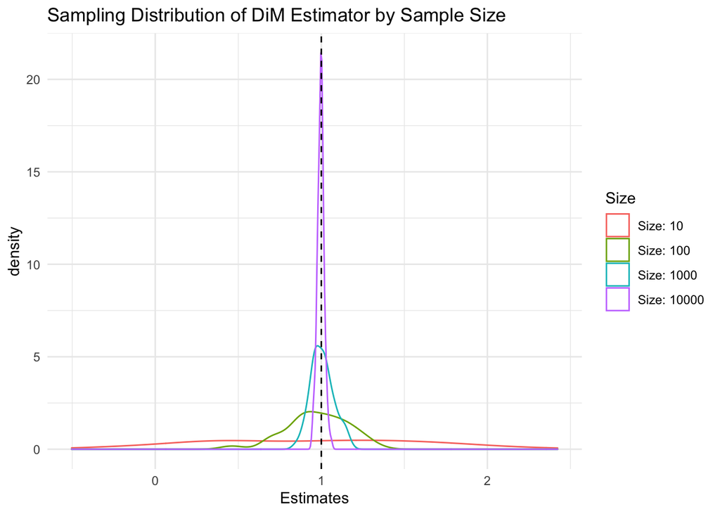

```r
?map_df

#FYI, it's apply family version in base R. Check yourself what the result looks like.
#sapply(10^c(1:4), function(n) replicate(100, classic_experiment(n)["estimate"]))

#let's plot
consist %>%
  gather(key="Size", value="Estimate") %>% #make it a long format grouped by Size
  ggplot(aes(x=Estimate, group=Size, col=Size)) +
  geom_density(aes(y=..density..)) +
  geom_vline(xintercept=1, linetype="dashed") + #true ATE
  labs(title="Sampling Distribution of DiM Estimator by Sample Size", x="Estimates") +
  theme_minimal()
```

**2. Stratified (Block) Randomization**

- Illustration of block randomization with potential outcomes.
- Now, let’s take a look at block randomization with R code. Suppose our guess is that region predicts the outcome, so we might want to adjust that covariate *before* treatment. 1) We make blocks based on `X` variable (US region), and then 2) randomly assign treatment within blocks with simple random assignment (West will be in block 1, Northeast in block 2, etc.).

```r
#make a helper function: randomly assign treatment within each block
block_random <- function(data){
  data$D <- NA #make a container column for treatment assignment vector, as one column of dataframe
  for(j in unique(data$J)){ #for loop: repeat from j=1 to j=J
    data$D[data$J==j] <- sample(c(0, 1), size = sum(data$J == j), replace = TRUE,
                                prob=c(.5, .5)) #randomize within block!(simple random assignment)
  }
  return(data)
}

#make a function to run a block randomized experiment
block_experiment <- function(n=100){ #set default size at 100
  tibble(i=1:n, #index for unit
         X = sample(c("West", "Northeast", "Midwest", "South"), n,
                    replace = TRUE, prob = c(.4, .1, .2, .3))) %>% #with probability .4, .1, .2, .3
    mutate(Y0 = case_when(X=="West" ~ rnorm(n, 4), #assume regional differences in potential outcomes
                          X=="Northeast" ~ rnorm(n, 3),
                          X=="Midwest" ~ rnorm(n,2),
                          X=="South" ~ rnorm(n,1)), #you can also use "TRUE ~ rnorm(n,1)" here
           Y1 = Y0 + 2, #treatment effect is 2
           J = case_when(X=="West" ~ 1, #regional differences in outcome
                         X=="Northeast" ~ 2,
                         X=="Midwest" ~ 3,
                         X=="South" ~ 4)) %>% #Block 1: West / Block 2: Northeast, ...
    block_random() %>% #randomize within each block using `block_random` function we made
    mutate(Y = if_else(D==1, Y1, Y0)) #turn on potential outcomes to observed outcomes
}
res <- block_experiment(1500)
```

First, a table with potential outcomes: we can see that four blocks $(J_i)$ are formed, treatment $(D_i)$ is randomly assigned within each block, and the observed outcome $(Y_i)$ is revealed according to treatment condition. Here are some sample data.

| $i$ | $X$ | $J_i$ (Block) | $Y_{0i}$ | $Y_{1i}$ | $\tau_i$ | $D_i$ | $Y_i$ |
| --- | --- | --- | --- | --- | --- | --- | --- |
| 1 | West | 1 | 1.968 | 3.968 | 2 | 0 | 1.968 |
| 2 | West | 1 | 3.752 | 5.752 | 2 | 1 | 5.752 |
| 5 | West | 1 | 3.447 | 5.447 | 2 | 0 | 3.447 |
| 7 | West | 1 | 4.392 | 6.392 | 2 | 1 | 6.392 |
| 8 | West | 1 | 3.907 | 5.907 | 2 | 1 | 5.907 |
| 11 | West | 1 | 4.092 | 6.092 | 2 | 1 | 6.092 |
| 14 | West | 1 | 4.640 | 6.640 | 2 | 0 | 4.640 |
| 16 | West | 1 | 3.429 | 5.429 | 2 | 1 | 5.429 |
| 19 | West | 1 | 4.859 | 6.859 | 2 | 1 | 6.859 |
| 20 | West | 1 | 3.358 | 5.358 | 2 | 1 | 5.358 |
| 4 | Northeast | 2 | 3.484 | 5.484 | 2 | 1 | 5.484 |
| 12 | Northeast | 2 | 3.175 | 5.175 | 2 | 1 | 5.175 |
| 3 | Midwest | 3 | 2.944 | 4.944 | 2 | 0 | 2.944 |
| 6 | Midwest | 3 | 1.930 | 3.930 | 2 | 1 | 3.930 |
| 13 | Midwest | 3 | 2.188 | 4.188 | 2 | 1 | 4.188 |
| 17 | Midwest | 3 | 3.398 | 5.398 | 2 | 1 | 5.398 |
| 18 | Midwest | 3 | 2.663 | 4.663 | 2 | 0 | 2.663 |
| 9 | South | 4 | 1.718 | 3.718 | 2 | 0 | 1.718 |
| 10 | South | 4 | -1.091 | 0.909 | 2 | 0 | -1.091 |
| 15 | South | 4 | 0.951 | 2.951 | 2 | 0 | 0.951 |

<sup>a</sup> counterfactual values are unobserved (grey-colored)

We have differences across blocks in outcome: we have to account for regional difference! So we conditioned on it.

```r
res %>%
  group_by(J) %>%
  summarize(Y0=mean(Y0), Y1=mean(Y1))
```

```
## # A tibble: 4 × 3
##       J    Y0    Y1
##   <dbl> <dbl> <dbl>
## 1     1 4.02   6.02
## 2     2 3.06   5.06
## 3     3 1.99   3.99
## 4     4 0.984  2.98
```

Check if block randomization worked well: probability of treatment within each block.

```r
res %>% group_by(J) %>% summarize(pr_treat = mean(D))
```

```
## # A tibble: 4 × 2
##       J pr_treat
##   <dbl>    <dbl>
## 1     1    0.511
## 2     2    0.521
## 3     3    0.533
## 4     4    0.494
```

Blocking is supposed to “balance” observed covariates (`X` or region here) across treatment arms, instead of leaving it up to chance to balance the covariates (randomization within each block will balance the rest, including unobservables, in expectation.)

```r
library(mosaic)
round(prop.table(table(Treatment=res$D, Block=res$J)), 3)
```

```
##          Block
## Treatment     1     2     3     4
##         0 0.199 0.052 0.091 0.147
##         1 0.208 0.057 0.103 0.143
```

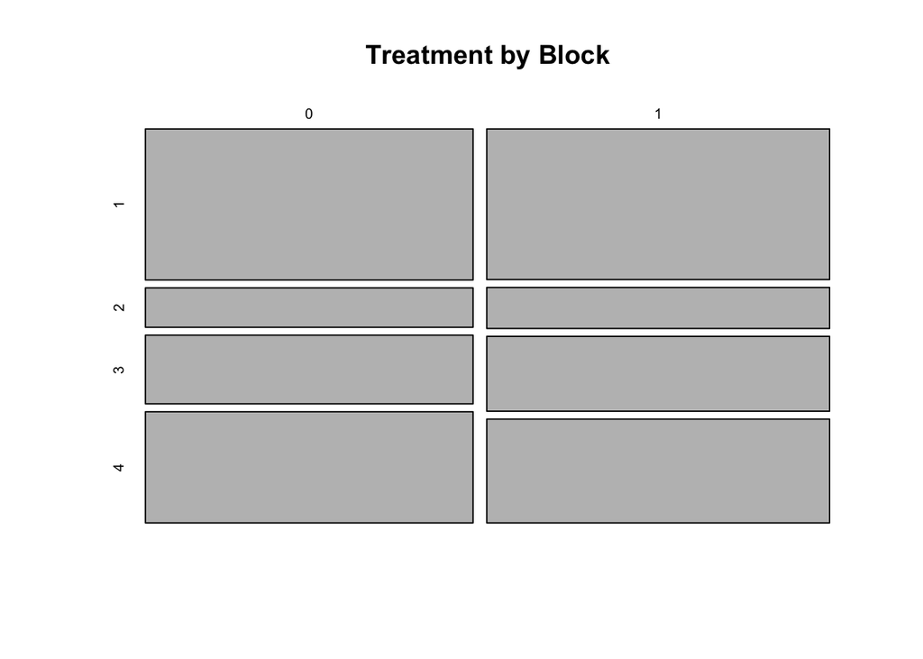

```r
mosaicplot(table(res$D, res$J), main = "Treatment by Block") #visualize
```

Now, estimation. The code was written to reveal every component for better understanding of the concept.

First, what if we use the naive DiM estimator, without considering blocking?

```r
#seems good because there's no heterogenous treat effect across blocks
res %>% summarize(est = mean(Y[D==1]) - mean(Y[D==0]))
```

```
## # A tibble: 1 × 1
##     est
##   <dbl>
## 1  2.06
```

Then, let’s use the conditional DiM estimator:
$$\sum_{j=1}^J \frac{n_j}{n}\hat{\tau}_j,$$
where $\hat{\tau}_j = \frac{1}{n_{1j}} \sum_{i=1}^{n_j} D_{ij}Y_{ij} - \frac{1}{n_{0j}} \sum_{i=1}^{n_j} (1-D_{ij})Y_{ij}$.

```r
#true ATE was
mean(res$Y1) - mean(res$Y0)
```

```
## [1] 2
```

```r
#conditional DiM estimator: sum_j (tau_j * Nj/N), where tau_j=DiM_j
#dplyr, dirty version
res %>% summarize(est = (mean(Y[D==1 & J==1]) - mean(Y[D==0 & J==1])) * mean(J==1) +
                        (mean(Y[D==1 & J==2]) - mean(Y[D==0 & J==2])) * mean(J==2) +
                        (mean(Y[D==1 & J==3]) - mean(Y[D==0 & J==3])) * mean(J==3) +
                        (mean(Y[D==1 & J==4]) - mean(Y[D==0 & J==4])) * mean(J==4))
```

```
## # A tibble: 1 × 1
##     est
##   <dbl>
## 1  2.03
```

```r
#base R version with for loop
block_weights <- prop.table(table(res$J))
tau_j <- numeric(4)
for (j in 1:4) {
  tau_j[j] <- mean(res$Y[res$D==1 & res$J==j]) - mean(res$Y[res$D==0 & res$J==j])
}
weighted.mean(tau_j, block_weights)
```

```
## [1] 2.034381
```

```r
#purrr version
#`map_dbl` returns output as a numeric vector
tau_j <- map_dbl(1:n_distinct(res$J), function(j)
    mean(res$Y[res$D==1 & res$J==j]) - mean(res$Y[res$D==0 & res$J==j]))
weighted.mean(tau_j, block_weights)
```

```
## [1] 2.034381
```

- Each approach has pros and cons. But let your code work, then clean it up later.

[figure not shown]

- The plot below shows what “we effectively run a separate experiment within each stratum” means!

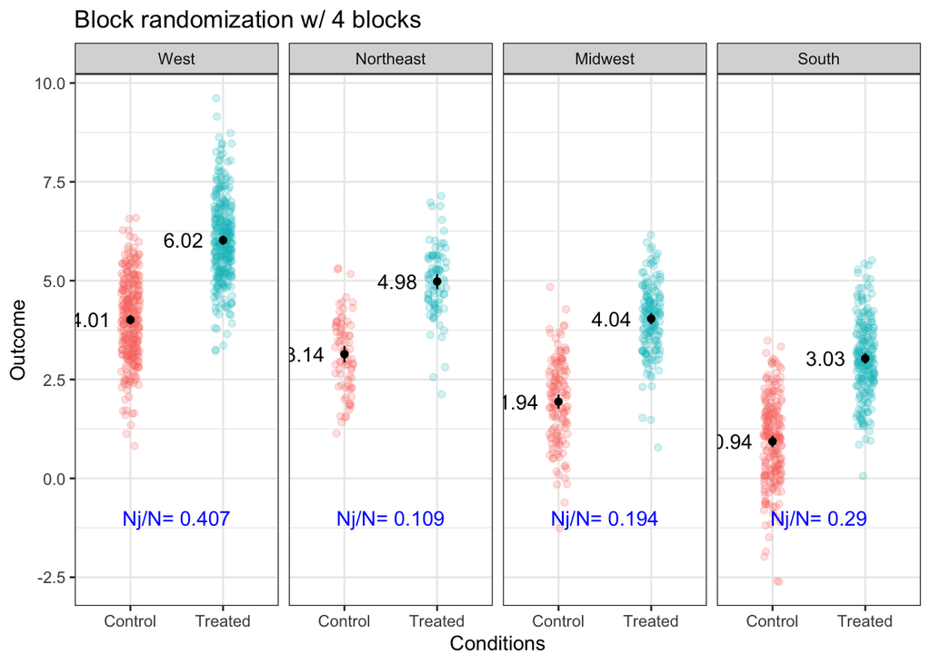